# Exposin Patterns of Inequlaity in Incarceration

Sunghee Park

2022-11-21

## Abstract

In this report, we will discuss the difference in many variables using the incarceration trend data collected by the Vera Institue. We will discuss growth of the U.S. Prison Population, growth of prison population by state, Difference in Black Prison Population Rate Between Rural and Urban Areas, and Difference in U.S. Jail Average Population Rate in 2018 Between Female and Male using different types of charts and graphs

## Introduction

**Mass incarceration** refers to how the United States criminalizes and inflicts enormous harm primarily on the most vulnerable people of their own: poor people of color. According to Vera Institute, more than 80% of all arrests are for low-level, nonviolent offenses and conduct related to poverty (Vera Institute). The direct stakeholder of this issue would be the poor people of color who are getting disproportionately hurt. It rips apart families and communities as many people who cannot pay court fines or bails for minor violation face jail time, which is criminalizing poverty. Not only this, but many people of color have been killed unfairly. One of the indirect stakeholders would be the taxpayers. Running prisons and incarcerating a single person costs thousands of dollars per year. The United States spends about $270 billion annually on their criminal justice system, and vast majority of the cost is by the taxpayers. This report is written to expose this pattern of inequality using the incarceration data.

In this report, I will be answering:

- What was the trend in jail population between 1970 and 2018?
- What was the difference in trend of jail population in the four different states in 1970-2018?
- How do rural and urban areas differ in rate of black prison population?
- How do average jail population rate differ between the two genders, male and female?

## Data Summary

In 2018, which is the most current year in the data set, there were 737,126.1 people in jail. Out of the population, 247,547 people were Black, which was 34% of the population. 7,076.18 people were Asian American / Pacific Islander, which was 1% of the population.

## Growth of the U.S. Jail Population

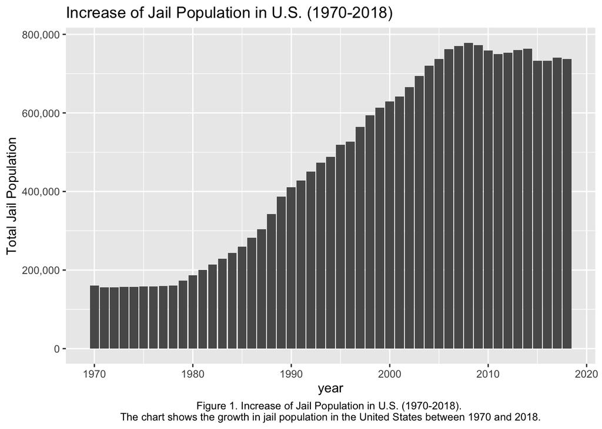

The chart illustrates the growth of the U.S. jail population from 1970 to 2018, answering the question of what was the trend in U.S. jail population between 1970 and 2018. From 1970 to 1978, there was no significant increase or decrease in population. However, in 1980, it starts to increase from about 150,000 to 772,897 in 2009. Over 30 years, the population has increased about 620,000. From 2010, there is no significant increase or decrease, but it is slowly decreasing until 2018, where it has reached 737126 people.

## Growth of Prison Population by State

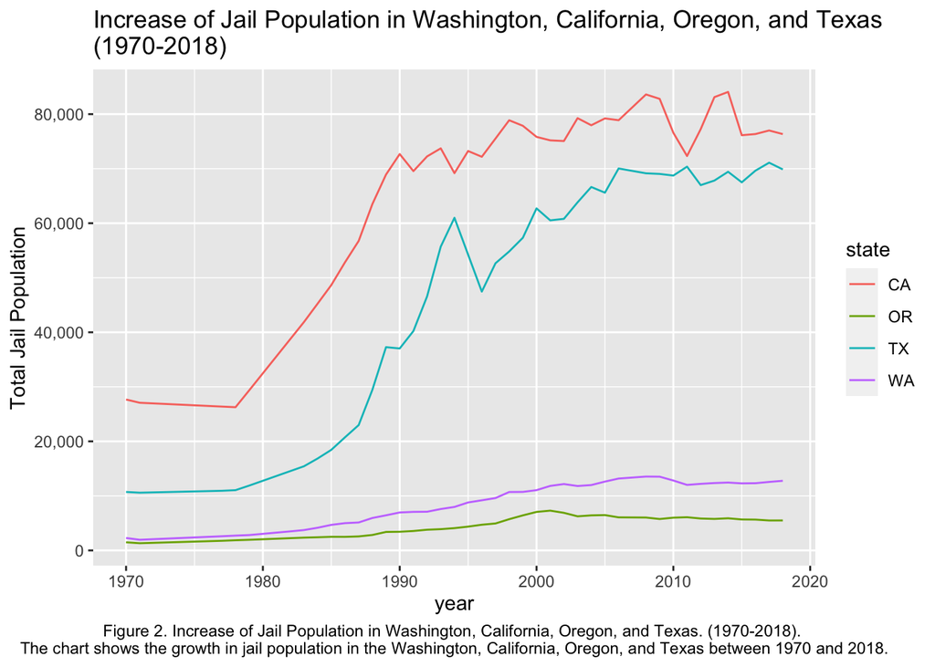

The chart illustrates the growth of the jail population in Washington, California, Oregon, and Texas from the year 1970 to 2018, answering the question of what was the difference in trend of jail population in the four different states. In 1970, California’s jail population was 27,672 which was significantly higher than other three states. Texas’s jail population was 10,720 which was less than the half of California’s jail population. Washington’s population was 2,277 and Oregon’s population was 1,487. While the population of California and Texas had increased drastically between 1978 and 1990, the population of Oregon and Washington has hardly increased.

## Difference in Black Prison Population Rate Between Rural and Urban Areas

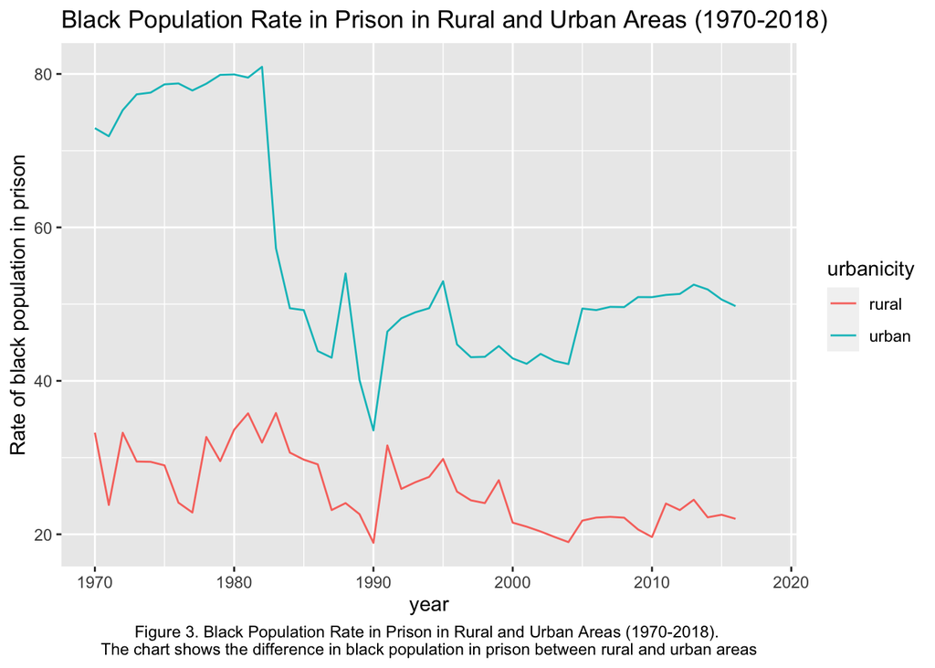

## Difference in U.S. Jail Average Population Rate in 2018 Between Female and Male

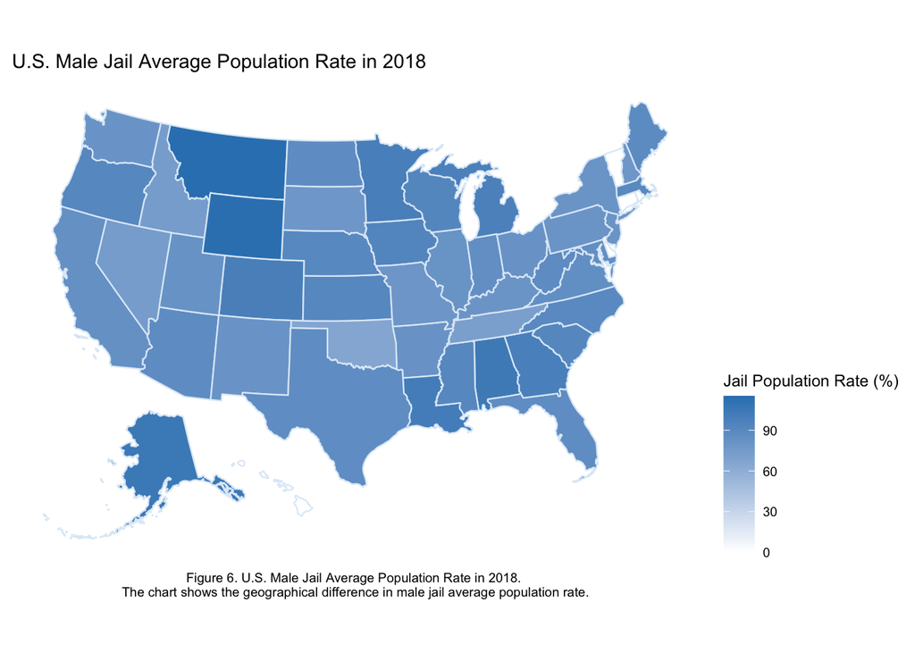

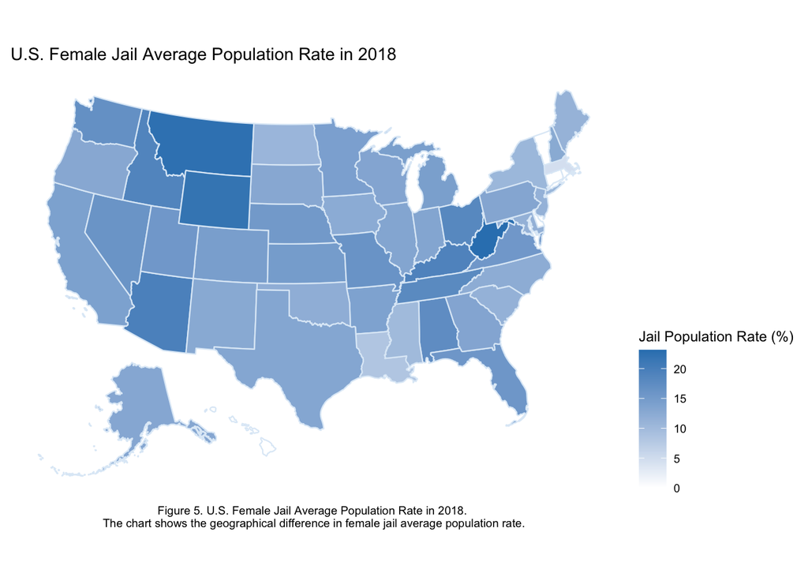

The chart portrays the difference in U.S. average jail population rate in 2018 between female and male, answering the question of how do average jail population rate differ between the two genders. Just by looking at the legend, it is apparent that overall, male has higher population rate than female; the average jail population rate of female is between 0% and 25% while the average jail population rate of male is between 0% and 100%. The highest average jail population rate was in Montana, and Wyoming for male and West Virginia, and Montana for female. The lowest average jail population rate was in Connecticut, Delaware, Hawaii, Rhode Island, and Vermont for both female and male.

## References

Criminalization & Racial Disparities. Vera Institute of Justice. (n.d.). Retrieved November 23, 2022, from https://www.vera.org/ending-mass-incarceration/criminalization-racial-disparities